Skip to neighborhood evidence

HBBremen Smart Governance

2024 reporting year · Release 2024-v1

# Neighborhood evidence for Bremen

Compare socioeconomic indicators, saved analytical results, and the gaps in coverage across Bremen’s Ortsteile.

**Student prototype, not an official Bremen municipal system.**

**Represented neighborhoods**

88

**Eligible and scored**

79

**Excluded from scoring**

9

## Explore neighborhoods

Select a neighborhood to see its 2024 values. Scoring requires all three source indicators. Unavailable results reflect missing inputs or exclusion from the scored sample.

88 neighborhoods

| Neighborhood | Code | Coverage |
| --- | --- | --- |
| Altstadt | 111 | Scored |
| Bahnhofsvorstadt | 112 | Scored |
| Ostertor | 113 | Scored |
| Industriehäfen | 122 | Excluded |
| Neustädter Hafen | 124 | Excluded |
| Hohentorshafen | 125 | Excluded |
| Alte Neustadt | 211 | Scored |
| Hohentor | 212 | Scored |
| Neustadt | 213 | Scored |
| Südervorstadt | 214 | Scored |
| Gartenstadt Süd | 215 | Scored |
| Buntentor | 216 | Scored |
| Neuenland | 217 | Scored |
| Huckelriede | 218 | Scored |
| Habenhausen | 231 | Scored |
| Arsten | 232 | Scored |
| Kattenturm | 233 | Scored |
| Kattenesch | 234 | Scored |
| Mittelshuchting | 241 | Scored |
| Sodenmatt | 242 | Scored |
| Kirchhuchting | 243 | Scored |
| Grolland | 244 | Scored |
| Woltmershausen | 251 | Scored |
| Rablinghausen | 252 | Scored |
| Seehausen | 261 | Scored |
| Strom | 271 | Excluded |
| Steintor | 311 | Scored |
| Fesenfeld | 312 | Scored |
| Peterswerder | 313 | Scored |
| Hulsberg | 314 | Scored |

[output cut: 58 more lines]

**View 9 exclusion reasons**

- Industriehäfen 122Unemployment quotient, Social-insurance employment, SGB II receipt
- Neustädter Hafen 124Unemployment quotient, Social-insurance employment, SGB II receipt
- Hohentorshafen 125Unemployment quotient, Social-insurance employment, SGB II receipt
- Strom 271Unemployment quotient, Social-insurance employment
- Blockland 411Unemployment quotient, Social-insurance employment
- In den Hufen 424Unemployment quotient, Social-insurance employment
- Hohweg 436Unemployment quotient, Social-insurance employment
- In den Wischen 444Unemployment quotient, Social-insurance employment, SGB II receipt
- Werderland 512Unemployment quotient, Social-insurance employment

### Altstadt

Ortsteil 111 · 2024

Scored

#### Socioeconomic indicators

**Unemployment quotient**

9.9128%

**Social-insurance employment**

63.6202%

**SGB II receipt**

13.2323%

#### Saved analytical results

**Composite Index**

0.3207

Rank 47

**TOPSIS**

0.3228

Rank 41

**K-means profile**

Profile A

**Housing floor area per resident**

43.74 m²

Rank 1 indicates the highest measured disadvantage in the scored sample. K-means profiles are nominal. Indicator definitions

### Bahnhofsvorstadt

Ortsteil 112 · 2024

Scored

#### Socioeconomic indicators

**Unemployment quotient**

20.2612%

**Social-insurance employment**

54.5375%

**SGB II receipt**

26.3826%

#### Saved analytical results

**Composite Index**

0.6982

Rank 9

**TOPSIS**

0.7256

Rank 8

**K-means profile**

Profile B

**Housing floor area per resident**

36.03 m²

Rank 1 indicates the highest measured disadvantage in the scored sample. K-means profiles are nominal. Indicator definitions

### Ostertor

Ortsteil 113 · 2024

Scored

#### Socioeconomic indicators

**Unemployment quotient**

9.7396%

**Social-insurance employment**

56.0384%

**SGB II receipt**

9.3679%

#### Saved analytical results

**Composite Index**

0.3678

Rank 42

**TOPSIS**

0.2738

Rank 49

**K-means profile**

Profile A

**Housing floor area per resident**

49.48 m²

Rank 1 indicates the highest measured disadvantage in the scored sample. K-means profiles are nominal. Indicator definitions

### Industriehäfen

Ortsteil 122 · 2024

Excluded

**Scoring exclusion.** Missing source indicators: Unemployment quotient, Social-insurance employment, SGB II receipt. Available source values are shown below.

#### Socioeconomic indicators

**Unemployment quotient**

Unavailable

**Social-insurance employment**

Unavailable

**SGB II receipt**

Unavailable

#### Saved analytical results

**Composite Index**

Unavailable

Rank Unavailable

**TOPSIS**

Unavailable

Rank Unavailable

**K-means profile**

Unavailable

**Housing floor area per resident**

Unavailable

Rank 1 indicates the highest measured disadvantage in the scored sample. K-means profiles are nominal. Indicator definitions

### Neustädter Hafen

Ortsteil 124 · 2024

Excluded

**Scoring exclusion.** Missing source indicators: Unemployment quotient, Social-insurance employment, SGB II receipt. Available source values are shown below.

#### Socioeconomic indicators

**Unemployment quotient**

Unavailable

**Social-insurance employment**

Unavailable

**SGB II receipt**

Unavailable

#### Saved analytical results

**Composite Index**

Unavailable

Rank Unavailable

**TOPSIS**

Unavailable

Rank Unavailable

**K-means profile**

Unavailable

**Housing floor area per resident**

Unavailable

Rank 1 indicates the highest measured disadvantage in the scored sample. K-means profiles are nominal. Indicator definitions

### Hohentorshafen

Ortsteil 125 · 2024

Excluded

**Scoring exclusion.** Missing source indicators: Unemployment quotient, Social-insurance employment, SGB II receipt. Available source values are shown below.

#### Socioeconomic indicators

**Unemployment quotient**

Unavailable

**Social-insurance employment**

Unavailable

**SGB II receipt**

Unavailable

#### Saved analytical results

**Composite Index**

Unavailable

Rank Unavailable

**TOPSIS**

Unavailable

Rank Unavailable

**K-means profile**

Unavailable

**Housing floor area per resident**

Unavailable

Rank 1 indicates the highest measured disadvantage in the scored sample. K-means profiles are nominal. Indicator definitions

### Alte Neustadt

Ortsteil 211 · 2024

Scored

#### Socioeconomic indicators

**Unemployment quotient**

10.7755%

**Social-insurance employment**

63.0608%

**SGB II receipt**

11.8067%

#### Saved analytical results

**Composite Index**

0.3244

Rank 45

**TOPSIS**

0.3181

Rank 44

**K-means profile**

Profile A

**Housing floor area per resident**

42.99 m²

Rank 1 indicates the highest measured disadvantage in the scored sample. K-means profiles are nominal. Indicator definitions

### Hohentor

Ortsteil 212 · 2024

Scored

#### Socioeconomic indicators

**Unemployment quotient**

14.1617%

**Social-insurance employment**

58.8347%

**SGB II receipt**

16.9981%

#### Saved analytical results

**Composite Index**

0.4715

Rank 29

**TOPSIS**

0.4649

Rank 31

**K-means profile**

Profile A

**Housing floor area per resident**

39.15 m²

Rank 1 indicates the highest measured disadvantage in the scored sample. K-means profiles are nominal. Indicator definitions

### Neustadt

Ortsteil 213 · 2024

Scored

#### Socioeconomic indicators

**Unemployment quotient**

8.5398%

**Social-insurance employment**

59.4037%

**SGB II receipt**

9.1456%

#### Saved analytical results

**Composite Index**

0.3102

Rank 50

**TOPSIS**

0.2418

Rank 56

**K-means profile**

Profile A

**Housing floor area per resident**

44.19 m²

Rank 1 indicates the highest measured disadvantage in the scored sample. K-means profiles are nominal. Indicator definitions

### Südervorstadt

Ortsteil 214 · 2024

Scored

#### Socioeconomic indicators

**Unemployment quotient**

10.8574%

**Social-insurance employment**

61.7319%

**SGB II receipt**

11.5999%

#### Saved analytical results

**Composite Index**

0.3389

Rank 44

**TOPSIS**

0.3182

Rank 43

**K-means profile**

Profile A

**Housing floor area per resident**

41.31 m²

Rank 1 indicates the highest measured disadvantage in the scored sample. K-means profiles are nominal. Indicator definitions

### Gartenstadt Süd

Ortsteil 215 · 2024

Scored

#### Socioeconomic indicators

**Unemployment quotient**

11.0753%

**Social-insurance employment**

62.8970%

**SGB II receipt**

16.5183%

#### Saved analytical results

**Composite Index**

0.3780

Rank 39

**TOPSIS**

0.3955

Rank 37

**K-means profile**

Profile A

**Housing floor area per resident**

38.15 m²

Rank 1 indicates the highest measured disadvantage in the scored sample. K-means profiles are nominal. Indicator definitions

### Buntentor

Ortsteil 216 · 2024

Scored

#### Socioeconomic indicators

**Unemployment quotient**

9.1590%

**Social-insurance employment**

62.2539%

**SGB II receipt**

9.1999%

#### Saved analytical results

**Composite Index**

0.2858

Rank 55

**TOPSIS**

0.2500

Rank 53

**K-means profile**

Profile A

**Housing floor area per resident**

43.96 m²

Rank 1 indicates the highest measured disadvantage in the scored sample. K-means profiles are nominal. Indicator definitions

### Neuenland

Ortsteil 217 · 2024

Scored

#### Socioeconomic indicators

**Unemployment quotient**

21.4192%

**Social-insurance employment**

58.4841%

**SGB II receipt**

23.5390%

#### Saved analytical results

**Composite Index**

0.6388

Rank 13

**TOPSIS**

0.6987

Rank 9

**K-means profile**

Profile B

**Housing floor area per resident**

40.36 m²

Rank 1 indicates the highest measured disadvantage in the scored sample. K-means profiles are nominal. Indicator definitions

### Huckelriede

Ortsteil 218 · 2024

Scored

#### Socioeconomic indicators

**Unemployment quotient**

14.2039%

**Social-insurance employment**

49.4697%

**SGB II receipt**

18.4156%

#### Saved analytical results

**Composite Index**

0.5957

Rank 19

**TOPSIS**

0.4970

Rank 25

**K-means profile**

Profile B

**Housing floor area per resident**

38.73 m²

Rank 1 indicates the highest measured disadvantage in the scored sample. K-means profiles are nominal. Indicator definitions

### Habenhausen

Ortsteil 231 · 2024

Scored

#### Socioeconomic indicators

**Unemployment quotient**

3.9635%

**Social-insurance employment**

63.2260%

**SGB II receipt**

2.4103%

#### Saved analytical results

**Composite Index**

0.1363

Rank 78

**TOPSIS**

0.0696

Rank 78

**K-means profile**

Profile A

**Housing floor area per resident**

56.21 m²

Rank 1 indicates the highest measured disadvantage in the scored sample. K-means profiles are nominal. Indicator definitions

### Arsten

Ortsteil 232 · 2024

Scored

#### Socioeconomic indicators

**Unemployment quotient**

8.1869%

**Social-insurance employment**

63.5861%

**SGB II receipt**

10.4755%

#### Saved analytical results

**Composite Index**

0.2702

Rank 58

**TOPSIS**

0.2488

Rank 54

**K-means profile**

Profile A

**Housing floor area per resident**

44.85 m²

Rank 1 indicates the highest measured disadvantage in the scored sample. K-means profiles are nominal. Indicator definitions

### Kattenturm

Ortsteil 233 · 2024

Scored

#### Socioeconomic indicators

**Unemployment quotient**

17.2187%

**Social-insurance employment**

54.8522%

**SGB II receipt**

23.6423%

#### Saved analytical results

**Composite Index**

0.6261

Rank 17

**TOPSIS**

0.6261

Rank 15

**K-means profile**

Profile B

**Housing floor area per resident**

35.97 m²

Rank 1 indicates the highest measured disadvantage in the scored sample. K-means profiles are nominal. Indicator definitions

### Kattenesch

Ortsteil 234 · 2024

Scored

#### Socioeconomic indicators

**Unemployment quotient**

8.1789%

**Social-insurance employment**

63.1743%

**SGB II receipt**

10.2200%

#### Saved analytical results

**Composite Index**

0.2723

Rank 56

**TOPSIS**

0.2452

Rank 55

**K-means profile**

Profile A

**Housing floor area per resident**

43.66 m²

Rank 1 indicates the highest measured disadvantage in the scored sample. K-means profiles are nominal. Indicator definitions

### Mittelshuchting

Ortsteil 241 · 2024

Scored

#### Socioeconomic indicators

**Unemployment quotient**

16.7629%

**Social-insurance employment**

55.4723%

**SGB II receipt**

25.7881%

#### Saved analytical results

**Composite Index**

0.6345

Rank 14

**TOPSIS**

0.6453

Rank 13

**K-means profile**

Profile B

**Housing floor area per resident**

37.11 m²

Rank 1 indicates the highest measured disadvantage in the scored sample. K-means profiles are nominal. Indicator definitions

### Sodenmatt

Ortsteil 242 · 2024

Scored

#### Socioeconomic indicators

**Unemployment quotient**

18.3211%

**Social-insurance employment**

55.1687%

**SGB II receipt**

26.8385%

#### Saved analytical results

**Composite Index**

0.6695

Rank 11

**TOPSIS**

0.6913

Rank 11

**K-means profile**

Profile B

**Housing floor area per resident**

33.92 m²

Rank 1 indicates the highest measured disadvantage in the scored sample. K-means profiles are nominal. Indicator definitions

### Kirchhuchting

Ortsteil 243 · 2024

Scored

#### Socioeconomic indicators

**Unemployment quotient**

18.9683%

**Social-insurance employment**

51.7413%

**SGB II receipt**

25.8837%

#### Saved analytical results

**Composite Index**

0.7085

Rank 8

**TOPSIS**

0.6958

Rank 10

**K-means profile**

Profile B

**Housing floor area per resident**

36.55 m²

Rank 1 indicates the highest measured disadvantage in the scored sample. K-means profiles are nominal. Indicator definitions

### Grolland

Ortsteil 244 · 2024

Scored

#### Socioeconomic indicators

**Unemployment quotient**

5.1546%

**Social-insurance employment**

63.8037%

**SGB II receipt**

4.3780%

#### Saved analytical results

**Composite Index**

0.1654

Rank 76

**TOPSIS**

0.1054

Rank 72

**K-means profile**

Profile A

**Housing floor area per resident**

51.31 m²

Rank 1 indicates the highest measured disadvantage in the scored sample. K-means profiles are nominal. Indicator definitions

### Woltmershausen

Ortsteil 251 · 2024

Scored

#### Socioeconomic indicators

**Unemployment quotient**

13.7232%

**Social-insurance employment**

59.9111%

**SGB II receipt**

17.3527%

#### Saved analytical results

**Composite Index**

0.4567

Rank 30

**TOPSIS**

0.4607

Rank 32

**K-means profile**

Profile A

**Housing floor area per resident**

40.91 m²

Rank 1 indicates the highest measured disadvantage in the scored sample. K-means profiles are nominal. Indicator definitions

### Rablinghausen

Ortsteil 252 · 2024

Scored

#### Socioeconomic indicators

**Unemployment quotient**

9.0731%

**Social-insurance employment**

72.4012%

**SGB II receipt**

10.9842%

#### Saved analytical results

**Composite Index**

0.1843

Rank 73

**TOPSIS**

0.2656

Rank 50

**K-means profile**

Profile A

**Housing floor area per resident**

45.48 m²

Rank 1 indicates the highest measured disadvantage in the scored sample. K-means profiles are nominal. Indicator definitions

### Seehausen

Ortsteil 261 · 2024

Scored

#### Socioeconomic indicators

**Unemployment quotient**

2.5896%

**Social-insurance employment**

72.7138%

**SGB II receipt**

2.8537%

#### Saved analytical results

**Composite Index**

0.0117

Rank 79

**TOPSIS**

0.0243

Rank 79

**K-means profile**

Profile A

**Housing floor area per resident**

52.93 m²

Rank 1 indicates the highest measured disadvantage in the scored sample. K-means profiles are nominal. Indicator definitions

### Strom

Ortsteil 271 · 2024

Excluded

**Scoring exclusion.** Missing source indicators: Unemployment quotient, Social-insurance employment. Available source values are shown below.

#### Socioeconomic indicators

**Unemployment quotient**

Unavailable

**Social-insurance employment**

Unavailable

**SGB II receipt**

2.8571%

#### Saved analytical results

**Composite Index**

Unavailable

Rank Unavailable

**TOPSIS**

Unavailable

Rank Unavailable

**K-means profile**

Unavailable

**Housing floor area per resident**

Unavailable

Rank 1 indicates the highest measured disadvantage in the scored sample. K-means profiles are nominal. Indicator definitions

### Steintor

Ortsteil 311 · 2024

Scored

#### Socioeconomic indicators

**Unemployment quotient**

8.1259%

**Social-insurance employment**

58.0798%

**SGB II receipt**

7.6244%

#### Saved analytical results

**Composite Index**

0.3048

Rank 51

**TOPSIS**

0.2159

Rank 58

**K-means profile**

Profile A

**Housing floor area per resident**

46.74 m²

Rank 1 indicates the highest measured disadvantage in the scored sample. K-means profiles are nominal. Indicator definitions

### Fesenfeld

Ortsteil 312 · 2024

Scored

#### Socioeconomic indicators

**Unemployment quotient**

7.4752%

**Social-insurance employment**

60.3419%

**SGB II receipt**

6.6715%

#### Saved analytical results

**Composite Index**

0.2600

Rank 59

**TOPSIS**

0.1864

Rank 62

**K-means profile**

Profile A

**Housing floor area per resident**

50.45 m²

Rank 1 indicates the highest measured disadvantage in the scored sample. K-means profiles are nominal. Indicator definitions

### Peterswerder

Ortsteil 313 · 2024

Scored

#### Socioeconomic indicators

**Unemployment quotient**

6.6321%

**Social-insurance employment**

61.2526%

**SGB II receipt**

5.5805%

#### Saved analytical results

**Composite Index**

0.2271

Rank 66

**TOPSIS**

0.1545

Rank 66

**K-means profile**

Profile A

**Housing floor area per resident**

49.67 m²

Rank 1 indicates the highest measured disadvantage in the scored sample. K-means profiles are nominal. Indicator definitions

### Hulsberg

Ortsteil 314 · 2024

Scored

#### Socioeconomic indicators

**Unemployment quotient**

10.0440%

**Social-insurance employment**

61.8262%

**SGB II receipt**

10.9108%

#### Saved analytical results

**Composite Index**

0.3199

Rank 48

**TOPSIS**

0.2923

Rank 46

**K-means profile**

Profile A

**Housing floor area per resident**

41.33 m²

Rank 1 indicates the highest measured disadvantage in the scored sample. K-means profiles are nominal. Indicator definitions

### Neu-Schwachhausen

Ortsteil 321 · 2024

Scored

#### Socioeconomic indicators

**Unemployment quotient**

6.1960%

**Social-insurance employment**

62.7481%

**SGB II receipt**

6.2779%

#### Saved analytical results

**Composite Index**

0.2109

Rank 68

**TOPSIS**

0.1517

Rank 67

**K-means profile**

Profile A

**Housing floor area per resident**

50.61 m²

Rank 1 indicates the highest measured disadvantage in the scored sample. K-means profiles are nominal. Indicator definitions

### Bürgerpark

Ortsteil 322 · 2024

Scored

#### Socioeconomic indicators

**Unemployment quotient**

4.9279%

**Social-insurance employment**

57.1738%

**SGB II receipt**

3.1566%

#### Saved analytical results

**Composite Index**

0.2274

Rank 65

**TOPSIS**

0.1150

Rank 71

**K-means profile**

Profile A

**Housing floor area per resident**

63.62 m²

Rank 1 indicates the highest measured disadvantage in the scored sample. K-means profiles are nominal. Indicator definitions

### Barkhof

Ortsteil 323 · 2024

Scored

#### Socioeconomic indicators

**Unemployment quotient**

5.3014%

**Social-insurance employment**

62.6622%

**SGB II receipt**

3.3107%

#### Saved analytical results

**Composite Index**

0.1699

Rank 75

**TOPSIS**

0.1014

Rank 73

**K-means profile**

Profile A

**Housing floor area per resident**

56.28 m²

Rank 1 indicates the highest measured disadvantage in the scored sample. K-means profiles are nominal. Indicator definitions

### Riensberg

Ortsteil 324 · 2024

Scored

#### Socioeconomic indicators

**Unemployment quotient**

6.0561%

**Social-insurance employment**

61.6233%

**SGB II receipt**

6.1703%

#### Saved analytical results

**Composite Index**

0.2210

Rank 67

**TOPSIS**

0.1503

Rank 68

**K-means profile**

Profile A

**Housing floor area per resident**

47.42 m²

Rank 1 indicates the highest measured disadvantage in the scored sample. K-means profiles are nominal. Indicator definitions

### Radio Bremen

Ortsteil 325 · 2024

Scored

#### Socioeconomic indicators

**Unemployment quotient**

6.6010%

**Social-insurance employment**

59.3675%

**SGB II receipt**

5.7509%

#### Saved analytical results

**Composite Index**

0.2504

Rank 63

**TOPSIS**

0.1608

Rank 65

**K-means profile**

Profile A

**Housing floor area per resident**

55.82 m²

Rank 1 indicates the highest measured disadvantage in the scored sample. K-means profiles are nominal. Indicator definitions

### Schwachhausen

Ortsteil 326 · 2024

Scored

#### Socioeconomic indicators

**Unemployment quotient**

4.1814%

**Social-insurance employment**

60.2361%

**SGB II receipt**

3.3517%

#### Saved analytical results

**Composite Index**

0.1836

Rank 74

**TOPSIS**

0.0926

Rank 75

**K-means profile**

Profile A

**Housing floor area per resident**

57.37 m²

Rank 1 indicates the highest measured disadvantage in the scored sample. K-means profiles are nominal. Indicator definitions

### Gete

Ortsteil 327 · 2024

Scored

#### Socioeconomic indicators

**Unemployment quotient**

5.6862%

**Social-insurance employment**

60.3256%

**SGB II receipt**

3.8647%

#### Saved analytical results

**Composite Index**

0.2079

Rank 69

**TOPSIS**

0.1211

Rank 70

**K-means profile**

Profile A

**Housing floor area per resident**

55.84 m²

Rank 1 indicates the highest measured disadvantage in the scored sample. K-means profiles are nominal. Indicator definitions

### Gartenstadt Vahr

Ortsteil 331 · 2024

Scored

#### Socioeconomic indicators

**Unemployment quotient**

9.1770%

**Social-insurance employment**

62.7467%

**SGB II receipt**

10.9357%

#### Saved analytical results

**Composite Index**

0.2979

Rank 52

**TOPSIS**

0.2750

Rank 48

**K-means profile**

Profile A

**Housing floor area per resident**

42.51 m²

Rank 1 indicates the highest measured disadvantage in the scored sample. K-means profiles are nominal. Indicator definitions

### Neue Vahr Nord

Ortsteil 332 · 2024

Scored

#### Socioeconomic indicators

**Unemployment quotient**

18.0061%

**Social-insurance employment**

56.7090%

**SGB II receipt**

26.2726%

#### Saved analytical results

**Composite Index**

0.6416

Rank 12

**TOPSIS**

0.6756

Rank 12

**K-means profile**

Profile B

**Housing floor area per resident**

32.08 m²

Rank 1 indicates the highest measured disadvantage in the scored sample. K-means profiles are nominal. Indicator definitions

### Neue Vahr Südwest

Ortsteil 334 · 2024

Scored

#### Socioeconomic indicators

**Unemployment quotient**

12.4279%

**Social-insurance employment**

63.2097%

**SGB II receipt**

19.7864%

#### Saved analytical results

**Composite Index**

0.4255

Rank 36

**TOPSIS**

0.4694

Rank 29

**K-means profile**

Profile A

**Housing floor area per resident**

34.66 m²

Rank 1 indicates the highest measured disadvantage in the scored sample. K-means profiles are nominal. Indicator definitions

### Neue Vahr Südost

Ortsteil 335 · 2024

Scored

#### Socioeconomic indicators

**Unemployment quotient**

16.7066%

**Social-insurance employment**

59.0784%

**SGB II receipt**

24.4699%

#### Saved analytical results

**Composite Index**

0.5783

Rank 22

**TOPSIS**

0.6225

Rank 16

**K-means profile**

Profile B

**Housing floor area per resident**

33.43 m²

Rank 1 indicates the highest measured disadvantage in the scored sample. K-means profiles are nominal. Indicator definitions

### Horn

Ortsteil 341 · 2024

Scored

#### Socioeconomic indicators

**Unemployment quotient**

4.5688%

**Social-insurance employment**

60.3467%

**SGB II receipt**

3.5513%

#### Saved analytical results

**Composite Index**

0.1895

Rank 72

**TOPSIS**

0.0993

Rank 74

**K-means profile**

Profile A

**Housing floor area per resident**

57.99 m²

Rank 1 indicates the highest measured disadvantage in the scored sample. K-means profiles are nominal. Indicator definitions

### Lehe

Ortsteil 342 · 2024

Scored

#### Socioeconomic indicators

**Unemployment quotient**

6.6759%

**Social-insurance employment**

54.1400%

**SGB II receipt**

6.2507%

#### Saved analytical results

**Composite Index**

0.3175

Rank 49

**TOPSIS**

0.1830

Rank 63

**K-means profile**

Profile A

**Housing floor area per resident**

39.55 m²

Rank 1 indicates the highest measured disadvantage in the scored sample. K-means profiles are nominal. Indicator definitions

### Lehesterdeich

Ortsteil 343 · 2024

Scored

#### Socioeconomic indicators

**Unemployment quotient**

7.3423%

**Social-insurance employment**

62.4753%

**SGB II receipt**

8.8795%

#### Saved analytical results

**Composite Index**

0.2557

Rank 61

**TOPSIS**

0.2108

Rank 60

**K-means profile**

Profile A

**Housing floor area per resident**

46.95 m²

Rank 1 indicates the highest measured disadvantage in the scored sample. K-means profiles are nominal. Indicator definitions

### Borgfeld

Ortsteil 351 · 2024

Scored

#### Socioeconomic indicators

**Unemployment quotient**

3.4463%

**Social-insurance employment**

57.1034%

**SGB II receipt**

1.7015%

#### Saved analytical results

**Composite Index**

0.1937

Rank 71

**TOPSIS**

0.0925

Rank 76

**K-means profile**

Profile A

**Housing floor area per resident**

55.45 m²

Rank 1 indicates the highest measured disadvantage in the scored sample. K-means profiles are nominal. Indicator definitions

### Oberneuland

Ortsteil 361 · 2024

Scored

#### Socioeconomic indicators

**Unemployment quotient**

5.4656%

**Social-insurance employment**

56.2020%

**SGB II receipt**

4.4713%

#### Saved analytical results

**Composite Index**

0.2592

Rank 60

**TOPSIS**

0.1376

Rank 69

**K-means profile**

Profile A

**Housing floor area per resident**

63.31 m²

Rank 1 indicates the highest measured disadvantage in the scored sample. K-means profiles are nominal. Indicator definitions

### Ellener Feld

Ortsteil 371 · 2024

Scored

#### Socioeconomic indicators

**Unemployment quotient**

8.1044%

**Social-insurance employment**

61.9301%

**SGB II receipt**

11.2453%

#### Saved analytical results

**Composite Index**

0.2962

Rank 53

**TOPSIS**

0.2617

Rank 51

**K-means profile**

Profile A

**Housing floor area per resident**

45.19 m²

Rank 1 indicates the highest measured disadvantage in the scored sample. K-means profiles are nominal. Indicator definitions

### Ellenerbrok-Schevemoor

Ortsteil 372 · 2024

Scored

#### Socioeconomic indicators

**Unemployment quotient**

11.8448%

**Social-insurance employment**

60.0425%

**SGB II receipt**

17.2843%

#### Saved analytical results

**Composite Index**

0.4293

Rank 35

**TOPSIS**

0.4243

Rank 36

**K-means profile**

Profile A

**Housing floor area per resident**

38.13 m²

Rank 1 indicates the highest measured disadvantage in the scored sample. K-means profiles are nominal. Indicator definitions

### Tenever

Ortsteil 373 · 2024

Scored

#### Socioeconomic indicators

**Unemployment quotient**

19.7758%

**Social-insurance employment**

51.2898%

**SGB II receipt**

30.2551%

#### Saved analytical results

**Composite Index**

0.7688

Rank 6

**TOPSIS**

0.7666

Rank 5

**K-means profile**

Profile B

**Housing floor area per resident**

31.35 m²

Rank 1 indicates the highest measured disadvantage in the scored sample. K-means profiles are nominal. Indicator definitions

### Osterholz

Ortsteil 374 · 2024

Scored

#### Socioeconomic indicators

**Unemployment quotient**

4.7340%

**Social-insurance employment**

65.1070%

**SGB II receipt**

3.6106%

#### Saved analytical results

**Composite Index**

0.1368

Rank 77

**TOPSIS**

0.0851

Rank 77

**K-means profile**

Profile A

**Housing floor area per resident**

46.98 m²

Rank 1 indicates the highest measured disadvantage in the scored sample. K-means profiles are nominal. Indicator definitions

### Blockdiek

Ortsteil 375 · 2024

Scored

#### Socioeconomic indicators

**Unemployment quotient**

15.4940%

**Social-insurance employment**

58.0992%

**SGB II receipt**

20.9611%

#### Saved analytical results

**Composite Index**

0.5380

Rank 25

**TOPSIS**

0.5501

Rank 21

**K-means profile**

Profile B

**Housing floor area per resident**

34.41 m²

Rank 1 indicates the highest measured disadvantage in the scored sample. K-means profiles are nominal. Indicator definitions

### Sebaldsbrück

Ortsteil 381 · 2024

Scored

#### Socioeconomic indicators

**Unemployment quotient**

10.9762%

**Social-insurance employment**

60.7894%

**SGB II receipt**

13.6393%

#### Saved analytical results

**Composite Index**

0.3721

Rank 40

**TOPSIS**

0.3519

Rank 39

**K-means profile**

Profile A

**Housing floor area per resident**

43.96 m²

Rank 1 indicates the highest measured disadvantage in the scored sample. K-means profiles are nominal. Indicator definitions

### Hastedt

Ortsteil 382 · 2024

Scored

#### Socioeconomic indicators

**Unemployment quotient**

11.5414%

**Social-insurance employment**

61.5617%

**SGB II receipt**

12.4187%

#### Saved analytical results

**Composite Index**

0.3583

Rank 43

**TOPSIS**

0.3437

Rank 40

**K-means profile**

Profile A

**Housing floor area per resident**

42.32 m²

Rank 1 indicates the highest measured disadvantage in the scored sample. K-means profiles are nominal. Indicator definitions

### Hemelingen

Ortsteil 383 · 2024

Scored

#### Socioeconomic indicators

**Unemployment quotient**

16.2271%

**Social-insurance employment**

56.7673%

**SGB II receipt**

23.5626%

#### Saved analytical results

**Composite Index**

0.5897

Rank 21

**TOPSIS**

0.6032

Rank 17

**K-means profile**

Profile B

**Housing floor area per resident**

36.55 m²

Rank 1 indicates the highest measured disadvantage in the scored sample. K-means profiles are nominal. Indicator definitions

### Arbergen

Ortsteil 384 · 2024

Scored

#### Socioeconomic indicators

**Unemployment quotient**

6.6427%

**Social-insurance employment**

63.6562%

**SGB II receipt**

9.9252%

#### Saved analytical results

**Composite Index**

0.2431

Rank 64

**TOPSIS**

0.2139

Rank 59

**K-means profile**

Profile A

**Housing floor area per resident**

46.57 m²

Rank 1 indicates the highest measured disadvantage in the scored sample. K-means profiles are nominal. Indicator definitions

### Mahndorf

Ortsteil 385 · 2024

Scored

#### Socioeconomic indicators

**Unemployment quotient**

9.2896%

**Social-insurance employment**

64.6453%

**SGB II receipt**

12.3786%

#### Saved analytical results

**Composite Index**

0.2918

Rank 54

**TOPSIS**

0.2971

Rank 45

**K-means profile**

Profile A

**Housing floor area per resident**

44.37 m²

Rank 1 indicates the highest measured disadvantage in the scored sample. K-means profiles are nominal. Indicator definitions

### Blockland

Ortsteil 411 · 2024

Excluded

**Scoring exclusion.** Missing source indicators: Unemployment quotient, Social-insurance employment. Available source values are shown below.

#### Socioeconomic indicators

**Unemployment quotient**

Unavailable

**Social-insurance employment**

Unavailable

**SGB II receipt**

1.9048%

#### Saved analytical results

**Composite Index**

Unavailable

Rank Unavailable

**TOPSIS**

Unavailable

Rank Unavailable

**K-means profile**

Unavailable

**Housing floor area per resident**

Unavailable

Rank 1 indicates the highest measured disadvantage in the scored sample. K-means profiles are nominal. Indicator definitions

### Regensburger Straße

Ortsteil 421 · 2024

Scored

#### Socioeconomic indicators

**Unemployment quotient**

9.1751%

**Social-insurance employment**

61.2270%

**SGB II receipt**

11.6620%

#### Saved analytical results

**Composite Index**

0.3229

Rank 46

**TOPSIS**

0.2880

Rank 47

**K-means profile**

Profile A

**Housing floor area per resident**

41.11 m²

Rank 1 indicates the highest measured disadvantage in the scored sample. K-means profiles are nominal. Indicator definitions

### Findorff-Bürgerweide

Ortsteil 422 · 2024

Scored

#### Socioeconomic indicators

**Unemployment quotient**

8.4704%

**Social-insurance employment**

64.0170%

**SGB II receipt**

10.6859%

#### Saved analytical results

**Composite Index**

0.2711

Rank 57

**TOPSIS**

0.2566

Rank 52

**K-means profile**

Profile A

**Housing floor area per resident**

42.16 m²

Rank 1 indicates the highest measured disadvantage in the scored sample. K-means profiles are nominal. Indicator definitions

### Weidedamm

Ortsteil 423 · 2024

Scored

#### Socioeconomic indicators

**Unemployment quotient**

7.2169%

**Social-insurance employment**

62.1634%

**SGB II receipt**

8.6612%

#### Saved analytical results

**Composite Index**

0.2554

Rank 62

**TOPSIS**

0.2058

Rank 61

**K-means profile**

Profile A

**Housing floor area per resident**

46.33 m²

Rank 1 indicates the highest measured disadvantage in the scored sample. K-means profiles are nominal. Indicator definitions

### In den Hufen

Ortsteil 424 · 2024

Excluded

**Scoring exclusion.** Missing source indicators: Unemployment quotient, Social-insurance employment. Available source values are shown below.

#### Socioeconomic indicators

**Unemployment quotient**

Unavailable

**Social-insurance employment**

Unavailable

**SGB II receipt**

0.9901%

#### Saved analytical results

**Composite Index**

Unavailable

Rank Unavailable

**TOPSIS**

Unavailable

Rank Unavailable

**K-means profile**

Unavailable

**Housing floor area per resident**

Unavailable

Rank 1 indicates the highest measured disadvantage in the scored sample. K-means profiles are nominal. Indicator definitions

### Utbremen

Ortsteil 431 · 2024

Scored

#### Socioeconomic indicators

**Unemployment quotient**

11.5039%

**Social-insurance employment**

61.8321%

**SGB II receipt**

20.1029%

#### Saved analytical results

**Composite Index**

0.4324

Rank 34

**TOPSIS**

0.4587

Rank 33

**K-means profile**

Profile A

**Housing floor area per resident**

34.41 m²

Rank 1 indicates the highest measured disadvantage in the scored sample. K-means profiles are nominal. Indicator definitions

### Steffensweg

Ortsteil 432 · 2024

Scored

#### Socioeconomic indicators

**Unemployment quotient**

12.2592%

**Social-insurance employment**

60.8379%

**SGB II receipt**

16.9187%

#### Saved analytical results

**Composite Index**

0.4219

Rank 37

**TOPSIS**

0.4255

Rank 35

**K-means profile**

Profile A

**Housing floor area per resident**

37.06 m²

Rank 1 indicates the highest measured disadvantage in the scored sample. K-means profiles are nominal. Indicator definitions

### Westend

Ortsteil 433 · 2024

Scored

#### Socioeconomic indicators

**Unemployment quotient**

13.6005%

**Social-insurance employment**

55.9518%

**SGB II receipt**

17.8020%

#### Saved analytical results

**Composite Index**

0.5058

Rank 26

**TOPSIS**

0.4694

Rank 28

**K-means profile**

Profile B

**Housing floor area per resident**

38.92 m²

Rank 1 indicates the highest measured disadvantage in the scored sample. K-means profiles are nominal. Indicator definitions

### Walle

Ortsteil 434 · 2024

Scored

#### Socioeconomic indicators

**Unemployment quotient**

14.9909%

**Social-insurance employment**

58.7810%

**SGB II receipt**

18.0283%

#### Saved analytical results

**Composite Index**

0.4936

Rank 27

**TOPSIS**

0.4962

Rank 26

**K-means profile**

Profile B

**Housing floor area per resident**

39.80 m²

Rank 1 indicates the highest measured disadvantage in the scored sample. K-means profiles are nominal. Indicator definitions

### Osterfeuerberg

Ortsteil 435 · 2024

Scored

#### Socioeconomic indicators

**Unemployment quotient**

16.1126%

**Social-insurance employment**

55.8158%

**SGB II receipt**

17.8779%

#### Saved analytical results

**Composite Index**

0.5417

Rank 24

**TOPSIS**

0.5186

Rank 23

**K-means profile**

Profile B

**Housing floor area per resident**

36.98 m²

Rank 1 indicates the highest measured disadvantage in the scored sample. K-means profiles are nominal. Indicator definitions

### Hohweg

Ortsteil 436 · 2024

Excluded

**Scoring exclusion.** Missing source indicators: Unemployment quotient, Social-insurance employment. Available source values are shown below.

#### Socioeconomic indicators

**Unemployment quotient**

Unavailable

**Social-insurance employment**

Unavailable

**SGB II receipt**

20.1087%

#### Saved analytical results

**Composite Index**

Unavailable

Rank Unavailable

**TOPSIS**

Unavailable

Rank Unavailable

**K-means profile**

Unavailable

**Housing floor area per resident**

Unavailable

Rank 1 indicates the highest measured disadvantage in the scored sample. K-means profiles are nominal. Indicator definitions

### Ueberseestadt

Ortsteil 437 · 2024

Scored

#### Socioeconomic indicators

**Unemployment quotient**

14.1290%

**Social-insurance employment**

47.6330%

**SGB II receipt**

19.4222%

#### Saved analytical results

**Composite Index**

0.6264

Rank 16

**TOPSIS**

0.5123

Rank 24

**K-means profile**

Profile B

**Housing floor area per resident**

47.21 m²

Rank 1 indicates the highest measured disadvantage in the scored sample. K-means profiles are nominal. Indicator definitions

### Lindenhof

Ortsteil 441 · 2024

Scored

#### Socioeconomic indicators

**Unemployment quotient**

22.2081%

**Social-insurance employment**

51.8087%

**SGB II receipt**

28.4106%

#### Saved analytical results

**Composite Index**

0.7766

Rank 5

**TOPSIS**

0.7964

Rank 4

**K-means profile**

Profile B

**Housing floor area per resident**

31.89 m²

Rank 1 indicates the highest measured disadvantage in the scored sample. K-means profiles are nominal. Indicator definitions

### Gröpelingen

Ortsteil 442 · 2024

Scored

#### Socioeconomic indicators

**Unemployment quotient**

25.2641%

**Social-insurance employment**

50.0423%

**SGB II receipt**

32.2077%

#### Saved analytical results

**Composite Index**

0.8765

Rank 2

**TOPSIS**

0.9112

Rank 2

**K-means profile**

Profile B

**Housing floor area per resident**

31.84 m²

Rank 1 indicates the highest measured disadvantage in the scored sample. K-means profiles are nominal. Indicator definitions

### Ohlenhof

Ortsteil 443 · 2024

Scored

#### Socioeconomic indicators

**Unemployment quotient**

27.5409%

**Social-insurance employment**

49.0596%

**SGB II receipt**

34.6216%

#### Saved analytical results

**Composite Index**

0.9428

Rank 1

**TOPSIS**

0.9706

Rank 1

**K-means profile**

Profile B

**Housing floor area per resident**

31.35 m²

Rank 1 indicates the highest measured disadvantage in the scored sample. K-means profiles are nominal. Indicator definitions

### In den Wischen

Ortsteil 444 · 2024

Excluded

**Scoring exclusion.** Missing source indicators: Unemployment quotient, Social-insurance employment, SGB II receipt. Available source values are shown below.

#### Socioeconomic indicators

**Unemployment quotient**

Unavailable

**Social-insurance employment**

Unavailable

**SGB II receipt**

Unavailable

#### Saved analytical results

**Composite Index**

Unavailable

Rank Unavailable

**TOPSIS**

Unavailable

Rank Unavailable

**K-means profile**

Unavailable

**Housing floor area per resident**

Unavailable

Rank 1 indicates the highest measured disadvantage in the scored sample. K-means profiles are nominal. Indicator definitions

### Oslebshausen

Ortsteil 445 · 2024

Scored

#### Socioeconomic indicators

**Unemployment quotient**

16.6022%

**Social-insurance employment**

53.5122%

**SGB II receipt**

22.2590%

#### Saved analytical results

**Composite Index**

0.6195

Rank 18

**TOPSIS**

0.5955

Rank 18

**K-means profile**

Profile B

**Housing floor area per resident**

34.70 m²

Rank 1 indicates the highest measured disadvantage in the scored sample. K-means profiles are nominal. Indicator definitions

### Burg-Grambke

Ortsteil 511 · 2024

Scored

#### Socioeconomic indicators

**Unemployment quotient**

13.6127%

**Social-insurance employment**

62.0972%

**SGB II receipt**

18.2562%

#### Saved analytical results

**Composite Index**

0.4388

Rank 32

**TOPSIS**

0.4698

Rank 27

**K-means profile**

Profile A

**Housing floor area per resident**

44.15 m²

Rank 1 indicates the highest measured disadvantage in the scored sample. K-means profiles are nominal. Indicator definitions

### Werderland

Ortsteil 512 · 2024

Excluded

**Scoring exclusion.** Missing source indicators: Unemployment quotient, Social-insurance employment. Available source values are shown below.

#### Socioeconomic indicators

**Unemployment quotient**

Unavailable

**Social-insurance employment**

Unavailable

**SGB II receipt**

5.1282%

#### Saved analytical results

**Composite Index**

Unavailable

Rank Unavailable

**TOPSIS**

Unavailable

Rank Unavailable

**K-means profile**

Unavailable

**Housing floor area per resident**

Unavailable

Rank 1 indicates the highest measured disadvantage in the scored sample. K-means profiles are nominal. Indicator definitions

### Burgdamm

Ortsteil 513 · 2024

Scored

#### Socioeconomic indicators

**Unemployment quotient**

17.2689%

**Social-insurance employment**

55.3956%

**SGB II receipt**

24.7451%

#### Saved analytical results

**Composite Index**

0.6316

Rank 15

**TOPSIS**

0.6418

Rank 14

**K-means profile**

Profile B

**Housing floor area per resident**

38.49 m²

Rank 1 indicates the highest measured disadvantage in the scored sample. K-means profiles are nominal. Indicator definitions

### Lesum

Ortsteil 514 · 2024

Scored

#### Socioeconomic indicators

**Unemployment quotient**

11.0516%

**Social-insurance employment**

56.4805%

**SGB II receipt**

15.0567%

#### Saved analytical results

**Composite Index**

0.4378

Rank 33

**TOPSIS**

0.3800

Rank 38

**K-means profile**

Profile A

**Housing floor area per resident**

45.96 m²

Rank 1 indicates the highest measured disadvantage in the scored sample. K-means profiles are nominal. Indicator definitions

### St. Magnus

Ortsteil 515 · 2024

Scored

#### Socioeconomic indicators

**Unemployment quotient**

9.2288%

**Social-insurance employment**

51.7043%

**SGB II receipt**

6.1761%

#### Saved analytical results

**Composite Index**

0.3793

Rank 38

**TOPSIS**

0.2358

Rank 57

**K-means profile**

Profile A

**Housing floor area per resident**

49.13 m²

Rank 1 indicates the highest measured disadvantage in the scored sample. K-means profiles are nominal. Indicator definitions

### Vegesack

Ortsteil 521 · 2024

Scored

#### Socioeconomic indicators

**Unemployment quotient**

16.2400%

**Social-insurance employment**

54.5885%

**SGB II receipt**

21.5853%

#### Saved analytical results

**Composite Index**

0.5953

Rank 20

**TOPSIS**

0.5775

Rank 19

**K-means profile**

Profile B

**Housing floor area per resident**

48.72 m²

Rank 1 indicates the highest measured disadvantage in the scored sample. K-means profiles are nominal. Indicator definitions

### Grohn

Ortsteil 522 · 2024

Scored

#### Socioeconomic indicators

**Unemployment quotient**

20.4433%

**Social-insurance employment**

44.1860%

**SGB II receipt**

26.3705%

#### Saved analytical results

**Composite Index**

0.8213

Rank 3

**TOPSIS**

0.7379

Rank 6

**K-means profile**

Profile B

**Housing floor area per resident**

36.77 m²

Rank 1 indicates the highest measured disadvantage in the scored sample. K-means profiles are nominal. Indicator definitions

### Schönebeck

Ortsteil 523 · 2024

Scored

#### Socioeconomic indicators

**Unemployment quotient**

10.0611%

**Social-insurance employment**

58.9977%

**SGB II receipt**

12.5184%

#### Saved analytical results

**Composite Index**

0.3695

Rank 41

**TOPSIS**

0.3202

Rank 42

**K-means profile**

Profile A

**Housing floor area per resident**

49.71 m²

Rank 1 indicates the highest measured disadvantage in the scored sample. K-means profiles are nominal. Indicator definitions

### Aumund-Hammersbeck

Ortsteil 524 · 2024

Scored

#### Socioeconomic indicators

**Unemployment quotient**

15.7159%

**Social-insurance employment**

55.9722%

**SGB II receipt**

19.8662%

#### Saved analytical results

**Composite Index**

0.5547

Rank 23

**TOPSIS**

0.5405

Rank 22

**K-means profile**

Profile B

**Housing floor area per resident**

42.54 m²

Rank 1 indicates the highest measured disadvantage in the scored sample. K-means profiles are nominal. Indicator definitions

### Fähr-Lobbendorf

Ortsteil 525 · 2024

Scored

#### Socioeconomic indicators

**Unemployment quotient**

17.4107%

**Social-insurance employment**

44.1589%

**SGB II receipt**

17.6689%

#### Saved analytical results

**Composite Index**

0.6930

Rank 10

**TOPSIS**

0.5511

Rank 20

**K-means profile**

Profile B

**Housing floor area per resident**

33.17 m²

Rank 1 indicates the highest measured disadvantage in the scored sample. K-means profiles are nominal. Indicator definitions

### Blumenthal

Ortsteil 531 · 2024

Scored

#### Socioeconomic indicators

**Unemployment quotient**

21.9825%

**Social-insurance employment**

51.1193%

**SGB II receipt**

29.7370%

#### Saved analytical results

**Composite Index**

0.7950

Rank 4

**TOPSIS**

0.8102

Rank 3

**K-means profile**

Profile B

**Housing floor area per resident**

37.72 m²

Rank 1 indicates the highest measured disadvantage in the scored sample. K-means profiles are nominal. Indicator definitions

### Rönnebeck

Ortsteil 532 · 2024

Scored

#### Socioeconomic indicators

**Unemployment quotient**

13.9403%

**Social-insurance employment**

58.1205%

**SGB II receipt**

17.4355%

#### Saved analytical results

**Composite Index**

0.4813

Rank 28

**TOPSIS**

0.4680

Rank 30

**K-means profile**

Profile B

**Housing floor area per resident**

45.01 m²

Rank 1 indicates the highest measured disadvantage in the scored sample. K-means profiles are nominal. Indicator definitions

### Lüssum-Bockhorn

Ortsteil 533 · 2024

Scored

#### Socioeconomic indicators

**Unemployment quotient**

19.3542%

**Social-insurance employment**

52.3915%

**SGB II receipt**

27.6394%

#### Saved analytical results

**Composite Index**

0.7238

Rank 7

**TOPSIS**

0.7264

Rank 7

**K-means profile**

Profile B

**Housing floor area per resident**

39.57 m²

Rank 1 indicates the highest measured disadvantage in the scored sample. K-means profiles are nominal. Indicator definitions

### Farge

Ortsteil 534 · 2024

Scored

#### Socioeconomic indicators

**Unemployment quotient**

13.2031%

**Social-insurance employment**

60.9602%

**SGB II receipt**

17.6980%

#### Saved analytical results

**Composite Index**

0.4410

Rank 31

**TOPSIS**

0.4549

Rank 34

**K-means profile**

Profile A

**Housing floor area per resident**

47.71 m²

Rank 1 indicates the highest measured disadvantage in the scored sample. K-means profiles are nominal. Indicator definitions

### Rekum

Ortsteil 535 · 2024

Scored

#### Socioeconomic indicators

**Unemployment quotient**

6.5708%

**Social-insurance employment**

65.0232%

**SGB II receipt**

7.9466%

#### Saved analytical results

**Composite Index**

0.2062

Rank 70

**TOPSIS**

0.1788

Rank 64

**K-means profile**

Profile A

**Housing floor area per resident**

53.88 m²

Rank 1 indicates the highest measured disadvantage in the scored sample. K-means profiles are nominal. Indicator definitions

### Indicator definitions · 2024

**Unemployment quotient**

Registered unemployed divided by registered unemployed plus employees covered by social insurance. The denominator differs from the conventional unemployment rate.

**Social-insurance employment**

Residents in social-insurance employment divided by residents aged 15 to under 65. It excludes self-employment and civil servants.

**SGB II receipt**

People eligible for SGB II benefits divided by residents under 65. It measures benefit receipt; unmet need can extend beyond this group.

## Housing and spatial context

These findings describe the 79 scored areas in the 2024 release.

### Housing context

Higher measured disadvantage was associated with less Atlas-reported residential floor area per resident. The saved Spearman correlation was **-0.8112**.

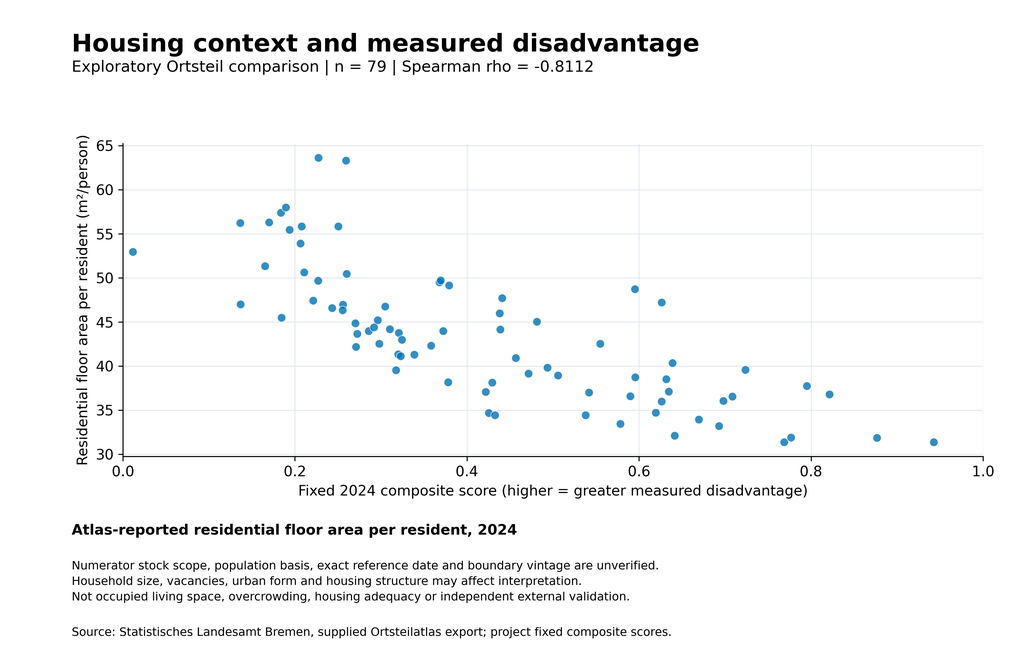

Saved housing benchmark, 2024. Floor area per resident alone cannot establish overcrowding. Individual area values appear in the neighborhood panel. Housing source

### Global Moran’s I

A release-level spatial finding for the saved Composite Index. Positive values indicate spatial clustering under the tested weights. The table gives no individual-neighborhood statistic.

| Neighbors (k) | Sample | Moran’s I | Two-sided p | Permutations |
| --- | --- | --- | --- | --- |
| 4 | 79 | 0.299181 | 0.0001 | 9999 |
| 6 | 79 | 0.200721 | 0.0011 | 9999 |

With 9,999 permutations and the plus-one correction, 0.0001 is the smallest attainable p-value. Zero extreme permutations still give an estimate of 0.0001, with simulation uncertainty. The underlying p-value may be smaller or larger.

Symmetrized, row-standardized nearest-neighbor weights use centroid distances in EPSG:25832. Permutation seed 2024. Results depend on the complete-case sample and the weights. They support no local hotspot, accessibility, or causal inference. Spatial source

## Proposed fieldwork

Three recommended candidates and two reserves form a purposive shortlist. No visits or field observations are recorded.

| Priority | Neighborhood | Role | Selection reason | Status |
| --- | --- | --- | --- | --- |
| 1 | Ohlenhof 443 | Recommended | Highest baseline composite score; higher measured economic disadvantage. | `proposed_not_visited` |
| 2 | Seehausen 261 | Recommended | Lowest baseline composite score; contrasting measured economic profile. | `proposed_not_visited` |
| 3 | Rablinghausen 252 | Recommended | Largest remaining absolute composite-TOPSIS rank gap. | `proposed_not_visited` |
| 4 | St. Magnus 515 | Reserve | Sensitivity-focused reserve: largest remaining rank span across 200 saved weight scenarios; not a confidence interval or a substitute for every visit role. | `proposed_not_visited` |
| 5 | Gröpelingen 442 | Reserve | Alternative high-disadvantage candidate: highest remaining composite score; reserve for the high-composite visit, not interchangeable with the sensitivity reserve. | `proposed_not_visited` |

The shortlist is for planning possible site visits, subject to approval. Shortlist source

## From evidence to a decision

A proposed human review sequence for evaluating options.

1. **Inspect indicators.** Check coverage, definitions, and saved results.
2. **Review local context.** Consider coverage gaps, local knowledge, and any future approved observations.
3. **Investigate service needs.** Use relevant service data and feedback to examine specific needs.
4. **Compare interventions.** Record the alternatives and the evidence behind each.
5. **Assess cost and feasibility.** Establish resources, constraints, and practical delivery conditions.
6. **Make a human-reviewed decision.** Document rationale and any pilot baseline, outcome measure, and review date.
7. **Monitor outcomes.** Review evidence and decide whether to adapt, stop, or extend any approved pilot.

## Sources and limitations

Repository references for the 2024 reporting year.

### Source citations

- Bremen Ortsteilatlas workbook, `Datentabelle.xls`. Project definitions and scoring methods in `analysis/data_dictionary.csv` and `docs/methods.md`.
- Integrated neighborhood data and provenance in `architecture/part2/releases/2024-v1/neighborhoods.csv` and `manifest.json`.
- Housing context from the Ortsteilatlas sheet Wohnungswesen I; saved evidence in `results/part2/housing_benchmark.csv` and `figures/part2/housing_benchmark.png`.
- Meriam’s spatial evidence, `architecture/part2/releases/2024-v1/spatial_summary.csv`, with archived official boundary data.
- Meriam’s shortlisted candidates, `results/part2/fieldwork_shortlist.csv`, carried through in the release.

### Methodological limitations

Scores use three selected indicators for complete cases. Rankings depend on method and coverage. Exact within-year source dates and denominator counts remain unverified. Missing inputs are not imputed. Results describe areas in a single reporting year and support no individual-level, longitudinal, or causal conclusions.

### Build provenance

Both release CSVs were checked against the manifest before the dashboard was generated. The housing figure was checked separately. Display rounding affects presentation only.

**Release**

2024-v1

**Source Git commit**

`fa2c6e277545391af3f6c92590f1447eb018f562`

**Neighborhoods · SHA-256**

`46e68d1ff5e93bc156ee8a4e065a4485739ee0eef5b794fc73b4aa94031caa97`

**Spatial summary · SHA-256**

`660f0663b9073b5daa52b13318214b482fb5079cf1571ae5ea2a2f3c0890d7fe`

**Housing figure · SHA-256**

`0f9e73737062b0073fab77080460a6c605789bd155c5654aa89ceacaa3f5ce34`